# Figure3.7

Ricky

2/9/2021

### Step 1 Draw power curves and box

For the picture we have got, we can add a box from 0.6 to 0.8, and bottom and top at height 0.05 and 0.95.

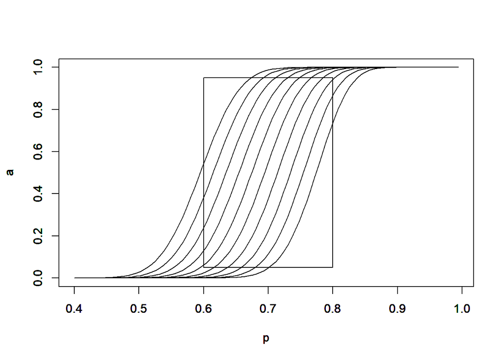

```r
p <- NA
a <- NA
n <- 100

for (t in 1:10){
  m = 60 + 2*(t-1)
  for (i in  1:100){
  p[i] = 0.4+0.006*(i-1)
  a[i] <- 1-pbinom(m-1, n, p[i])
}
plot(p,a,type = "l")

par(new=TRUE)
}

rect(0.6,0.05,0.8,0.95)
```

### Step 2 Calculate the range of m

From the picture we have got, we can find that, some curves has the $\alpha$ value more than 0.05 when given the p = 0.6. Also when given p = 0.8, some curves has a $\beta$ value more than 0.05.

So take this two criterion, we can calculate the range of m.

1. type 1 error criterion: p = 0.6, a < 0.05
2. type 2 error criterion: p = 0.8, b < 0.05

```r
b <- NA

for (m in 1:100){
  for (i in  1:100){
  a[m] <- 1-pbinom(m-1, n, 0.6)
  b[m] <- 1-a[m]
  }
}

M <- which(a < 0.05)
M1 <- M[1]

for (m in 1:100){
  for (i in  1:100){
  a[m] <- 1-pbinom(m-1, n, 0.8)
  b[m] <- 1-a[m]
  }
}

M <- which(b < 0.05)
M2 <- M[length(M)]

cat("Rannge of M:[",M1,",",M2,"]")
```

```
## Rannge of M:[ 69 , 73 ]
```

### Step 3 Drew the Power Curve of figure 7.3

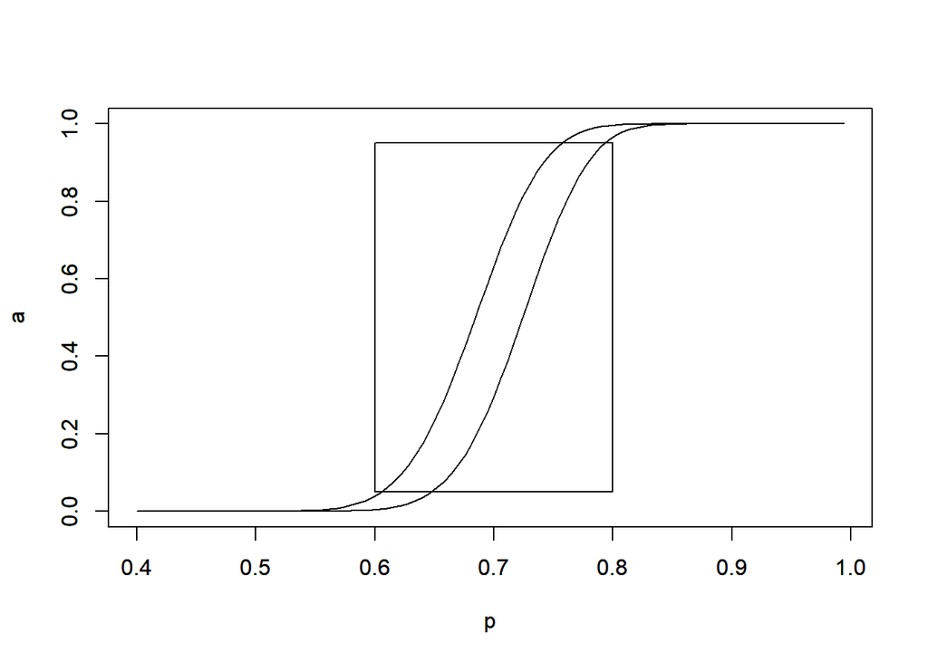

```r
for (i in  1:100){
  p[i] = 0.4+0.006*(i-1)
  a[i] <- 1-pbinom(M1-1, n, p[i])
}
plot(p,a,type = "l")

par(new=TRUE)

for (i in  1:100){
  p[i] = 0.4+0.006*(i-1)
  a[i] <- 1-pbinom(M2-1, n, p[i])
}
plot(p,a,type = "l")
rect(0.6,0.05,0.8,0.95)
```

So When m increases, we will expect the power curve moves to right side, and the decrease of $\alpha$, and expect the increase of $\beta$. When we want to get less type 1 error, then we will choose a lager m, but no more than 73, the criterion for type 2 error; also when we want to get less type 2 error, then we will choose a smaller m, but no less than 69, the criterion for type 1 error.